# The whole elephant

Rick Gilmore

2017-06-05

*A couple of months ago, I was feeling rather cranky about the state of our political union. Still am, truth be told. At that time the working title of this piece was “Making psychology great.” But the current title better reflects the spirit I hoped to capture. Psychology is already great and wonderful in so many ways. I just want to see the whole elephant, don’t you? So, here’s my manifesto.*

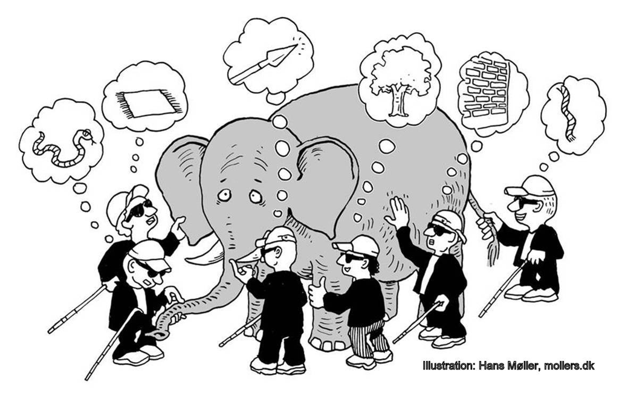

### Psychology is not inherently less reproducible than other sciences, but we must restore psychology’s credibility nonetheless.

Psychologists have surely cast an early, bright light on our field’s methodological and related failings. But as Richard Harris shows in [*Rigor Mortis*](http://www.npr.org/books/titles/522223284/rigor-mortis-how-sloppy-science-creates-worthless-cures-crushes-hope-and-wastes) and cross-field [surveys](http://doi.org/10.1038/533452a) show, the problem affects many areas of science – chemistry, physics and engineering, biomedical sciences, and the Earth sciences.

[Chris Chambers](http://press.princeton.edu/titles/10970.html) and others argue that many of psychology’s problems are self-inflicted, perhaps even ‘sinful’. I don’t disagree at all, but I find more motivation in the argument that that transparency leads to reproducible results; reproducible results foster robust findings; robust findings lead to important insights; and important insights lead to meaningful impact. This line of reasoning implies that transparency is a first step on the path to restoring psychology’s scientific credibility.

### Psychology is harder than physics

Psychology is a scientific field that aspires to develop generalizable, quantifiable laws about human behavior. Let’s acknowledge an inconvenient and not widely known truth: Psychology is simply much, much harder than physics.

Consider a spheroid-shaped mass $m$ positioned on top of an inclined plan at angle $theta$, $h$ units above a ground plane in gravitational field $g$ with a downward acceleration equal to 9.8 $m/s^2$. First term physics students know that they can predict what will happen next with great spatial and temporal precision based on these simple facts: The mass will slide (if we ignore friction) or roll (if we do not) at a speed specified by a simple set of equations that involve straightforward algebraic operations.

Now consider a **mouse** under the same conditions. What happens next? I’ve asked my students this question for years, and the best, most accurate answer is: It depends. What does it depend on? Any number of things we don’t (and perhaps can’t or can’t easily know) – characteristics of the mouse, the wedge (made of cheese or not), time of day, season of year, and so on.

Clearly, any laws of behavior will have more than the 10 dimensions of string theory, several orders of magnitude more. Moreover, the laws of behavior are stochastic and probabilistic. A hungry mouse might just bite a wedge of cheese, gravity be damned, or she might not. Behavioral laws might even be subject to uncertainty principles like Heisenberg’s that limit the resolution with which we can determine one variable when measuring another.

I suggest that the essential difficulty of psychological science is one (too often neglected) reason why we must clean up our own house. Psychologists sometimes joke about having ‘physics envy’, a less than subtle allusion to Freud. It’s fine to have physics envy, but only for the right reasons. Let’s envy their success in getting big bucks to build instruments to study fundamental questions about our physical world (Hubble, LHC, fusion reactors, etc.). Let’s envy their great PR (huge portions of my science news feed are about astronomy/physics related topics), their adoption of open data and preprint publication ([ArXiv](http://arxiv.org) practices, embrace of replication, and their ambition to discern universal quantifiable laws. But our envy should have limits. After all, I have physics colleagues who confess that some unknown fraction of the published physics literature is wrong because no one has checked the math. Let’s make sure psychologists check our own math.

### Psychology is not harder than biology, but biology sometimes neglects behavior

Psychology sits, sometimes uncomfortably, between the social and biological sciences. But just as biology incorporates and extends physics and chemistry, psychology incorporates and extends biology. With some exceptions, biology too often forgets about behavior. Behavior is the phenotype without which the genotype means little. Behavior is the output from the nervous system’s connections. Behavior is essential for reproduction in complex organisms; and relative reproductive success is the core of evolutionary processes. The most vexing problems in biomedicine and health promotion involve behavior – preventing heart disease, diabetes, cancers associated with environmental risk, and mental health.

Like physics, biomedicine has also benefited from significant investments in big data infrastructure and data sharing informatics – human genome project, human connectome project, human microbiome project. Maybe someone has suggested launching a human behaviorome, and I’ve missed it. But don’t we need a more comprehensive understanding of human behavior to understand the other ’omes?

*In the second part of this post, I’ll talk about how restoring behavior to a central place in psychology, coupled with some very achievable changes in practice, can help us begin to see the whole elephant.*